# Musterloesung Aufgabe 2.3S ANOVA mit Interaktion

Statistik2

Statistik

- **Lese-Empfehlung** Kapitel 7 von [Manny Gimond](https://mgimond.github.io/Stats-in-R/ANOVA.html)
- Download R-Skript
- Download PDF

**kommentierter Lösungsweg**

```r
# klone den originaler Datensatz
df <- nova

# Daten vorbereiten
df %<>% # schaut euch das Package "magrittr" an
  # ersetze Local mit einem leeren String
  mutate(article_description = str_replace(article_description, "Local ", "")) %>%
  filter(article_description != "Hot and Cold") %>% # lasse Buffet Gerichte weg
  filter(member != "Spezialkarten") %>% # Spezialkarten können vernachlässigt werden
  #  fasse die zwei Menülinien "World & Favorite" zusammen
  mutate(article_description = str_replace_all(article_description, "Favorite|World",
                                               "Fav_World"))

# gruppiere Daten nach Menülinie, Geschlecht und Hochschulzugehörigkeit
df %<>%
    group_by(article_description, member, week) %>%
    summarise(tot_sold = n()) %>%
    ungroup() %>%
    drop_na()  # lasst die unbekannten Menü-Inhalte weg

# überprüft die Voraussetzungen für eine ANOVA
# Schaut euch die Verteilungen der Mittelwerte der Responsevariable an
# Sind Mittelwerte nahe bei Null? Gäbe uns einen weiteren Hinweis auf
# eine spezielle Binomail-Verteilung (vgl. Statistik 4)
df %>%
  split(.$article_description) %>% # teilt den Datensatz in 3 verschiedene Datensätze auf
  # mit map können andere Funktionen auf den Datensatz angewendet werden
  # (alternative Funktionen sind aggregate oder apply)
  purrr::map(~ psych::describe(.$tot_sold))
```

```
$Fav_World
   vars  n   mean     sd median trimmed    mad min max range skew
X1    1 24 622.67 178.79  599.5   620.8 253.52 378 876   498 0.04
   kurtosis   se
X1    -1.88 36.5

$Kitchen
   vars  n  mean    sd median trimmed   mad min max range skew
X1    1 24 128.5 22.21  124.5   128.2 23.72  79 187   108 0.27
   kurtosis   se
X1     0.43 4.53
```

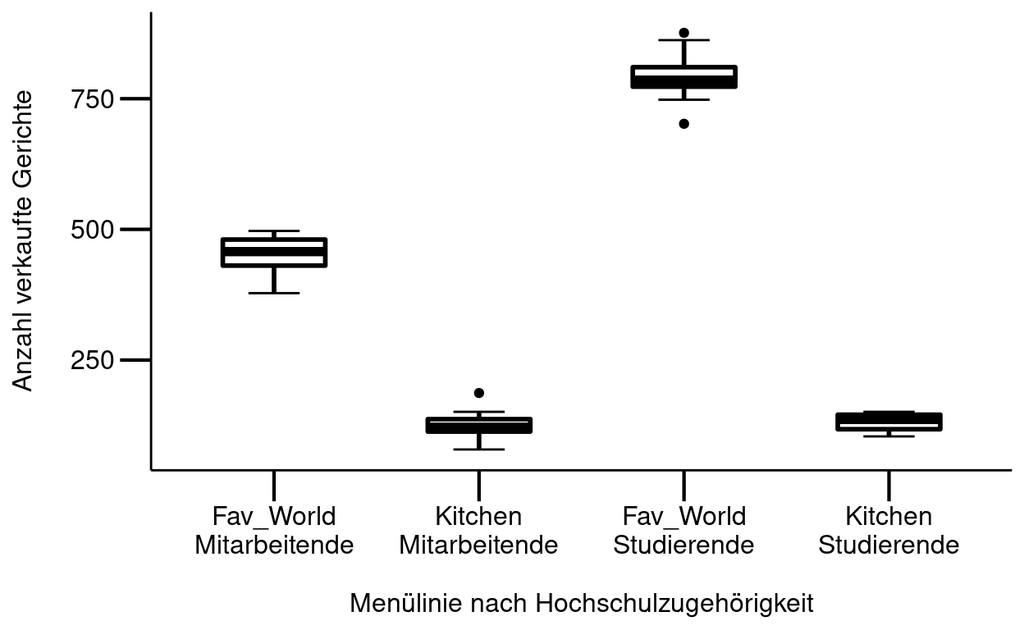

```r
# visualisiere dir dein Model, was siehst du?
# sind möglicherweise gewiesse Voraussetzungen verletzt?
# Boxplot
ggplot(df, aes(x = interaction(article_description, member), y= tot_sold)) +
   # Achtung: Reihenfolge spielt hier eine Rolle!
  stat_boxplot(geom = "errorbar", width = 0.25) +
  geom_boxplot(fill="white", color = "black", size = 1, width = .5) +
  labs(x = "\nMenülinie nach Hochschulzugehörigkeit", y = "Anzahl verkaufte Gerichte\n") +
  scale_x_discrete(limits = c("Fav_World.Mitarbeitende", "Kitchen.Mitarbeitende",
                              "Fav_World.Studierende", "Kitchen.Studierende"),
                   breaks = c("Fav_World.Mitarbeitende", "Fav_World.Studierende",
                              "Kitchen.Mitarbeitende",  "Kitchen.Studierende"),
                   labels = c("Fav_World\nMitarbeitende", "Fav_World\nStudierende",
                              "Kitchen\nMitarbeitende",  "Kitchen\nStudierende")) +
  mytheme # wie sind die Voraussetzungen erfüllt?
```

```r
# definiert das Modell (Skript Statistik 2)
model <- aov(tot_sold ~ article_description * member, data = df)

summary.lm(model)
```

```
Call:
aov(formula = tot_sold ~ article_description * member, data = df)

Residuals:
   Min     1Q Median     3Q    Max
-91.00 -17.33   0.50  14.83  83.00

Coefficients:
                                             Estimate Std. Error
(Intercept)                                   452.333      9.734
article_descriptionKitchen                   -327.000     13.766
memberStudierende                             340.667     13.766
article_descriptionKitchen:memberStudierende -334.333     19.469
                                             t value Pr(>|t|)
(Intercept)                                    46.47   <2e-16 ***
article_descriptionKitchen                    -23.75   <2e-16 ***
memberStudierende                              24.75   <2e-16 ***
article_descriptionKitchen:memberStudierende  -17.17   <2e-16 ***
---
Signif. codes:  0 '***' 0.001 '**' 0.01 '*' 0.05 '.' 0.1 ' ' 1

Residual standard error: 33.72 on 44 degrees of freedom
Multiple R-squared:  0.9864,    Adjusted R-squared:  0.9855
F-statistic:  1063 on 3 and 44 DF,  p-value: < 2.2e-16
```

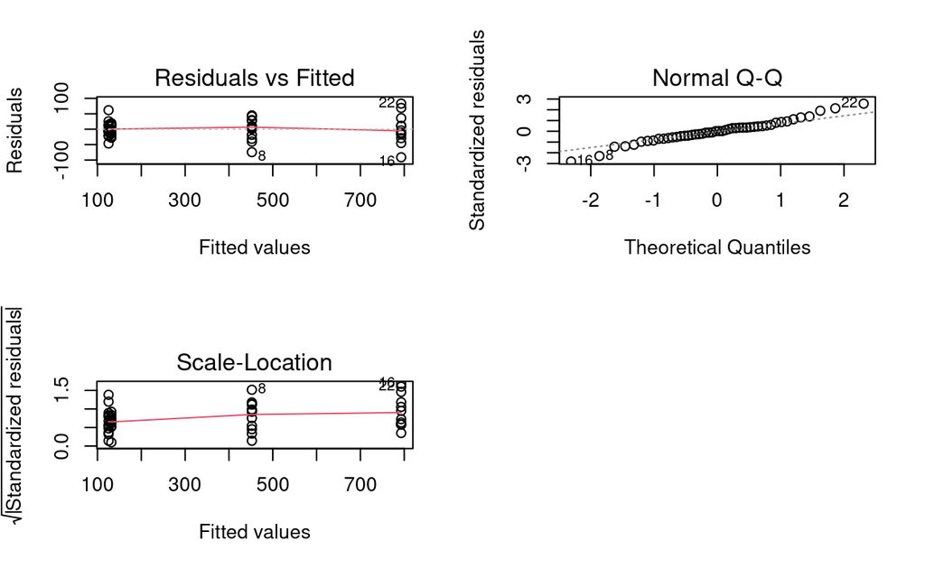

```r
# überprüft die Modelvoraussetzungen (Statistik 2)
par(mfrow = c(2,2)) # alternativ gäbe es die ggfortify::autoplot(model) funktion
plot(model)
```

**Fazit**: Die Inspektion des Modells zeigt kleinere Verletzungen bei der Normalverteilung der Residuen (Q-Q Plot). Aufgrund keiner starken Verbesserung durch eine Transformation der Responsevariable, entscheide ich mich für eine ANOVA ohne log-tranformierten Responsevariablen (AV).

```r
# sieht aus, als ob die Voraussetzungen für eine Anova nur geringfügig verletzt sind
# mögliche alternativen:
# 1. log-transformation um die grossen werte zu minimieren (nur möglich, wenn
# keine 0 enthalten sind und die Mittelwerte weit von 0 entfernt sind
# => bei Zähldaten ist dies leider nicht immer gegeben)
# 2. nicht parametrische Test z.B. Welch-Test, da hohe Varianzheterogenität
# zwischen den Residuen


#1) log-transformation
model_log <- aov(log10(tot_sold) ~ article_description * member, data = df)

summary.lm(model_log) # interaktion ist nun nicht mehr signifikant: vgl.
```

```
Call:
aov(formula = log10(tot_sold) ~ article_description * member,
    data = df)

Residuals:
      Min        1Q    Median        3Q       Max
-0.191372 -0.025043  0.003191  0.037604  0.182842

Coefficients:
                                             Estimate Std. Error
(Intercept)                                   2.65417    0.01696
article_descriptionKitchen                   -0.56517    0.02398
memberStudierende                             0.24438    0.02398
article_descriptionKitchen:memberStudierende -0.21726    0.03391
                                             t value Pr(>|t|)
(Intercept)                                  156.533  < 2e-16 ***
article_descriptionKitchen                   -23.569  < 2e-16 ***
memberStudierende                             10.191 3.71e-13 ***
article_descriptionKitchen:memberStudierende  -6.407 8.51e-08 ***
---
Signif. codes:  0 '***' 0.001 '**' 0.01 '*' 0.05 '.' 0.1 ' ' 1

Residual standard error: 0.05874 on 44 degrees of freedom
Multiple R-squared:  0.9745,    Adjusted R-squared:  0.9728
F-statistic: 561.4 on 3 and 44 DF,  p-value: < 2.2e-16
```

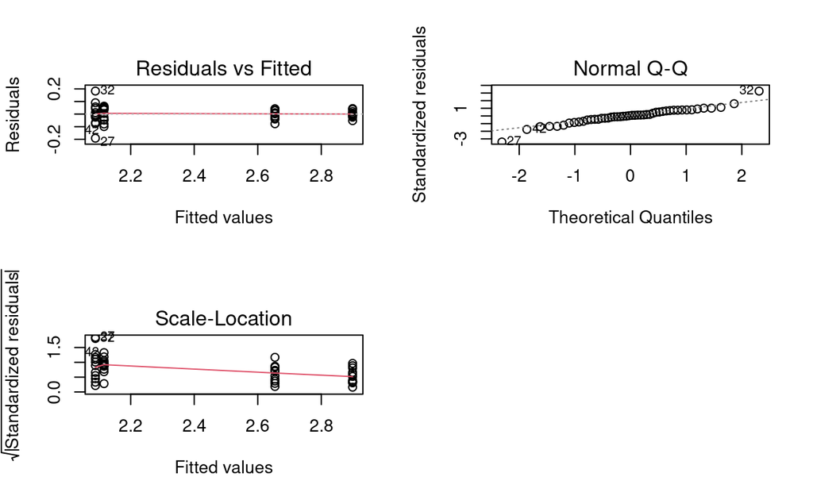

```r
# nochmals euren Boxplot zu beginn, machen diese Koeffizienten sinn?

# überprüft die Modelvoraussetzungen (vgl. Skript Statistik 2)
# bringt aber keine wesentliche Verbesserung, daher bleibe ich bei den
# untranfromierten Daten
par(mfrow = c(2,2))
plot(model_log)
```

```r
# post-hov Vergleiche
TukeyHSD(model)
```

```
  Tukey multiple comparisons of means
    95% family-wise confidence level

Fit: aov(formula = tot_sold ~ article_description * member, data = df)

$article_description
                       diff      lwr       upr p adj
Kitchen-Fav_World -494.1667 -513.785 -474.5484     0

$member
                           diff      lwr      upr p adj
Studierende-Mitarbeitende 173.5 153.8817 193.1183     0

$`article_description:member`
                                                     diff        lwr
Kitchen:Mitarbeitende-Fav_World:Mitarbeitende -327.000000 -363.75650
Fav_World:Studierende-Fav_World:Mitarbeitende  340.666667  303.91017
Kitchen:Studierende-Fav_World:Mitarbeitende   -320.666667 -357.42317
Fav_World:Studierende-Kitchen:Mitarbeitende    667.666667  630.91017
Kitchen:Studierende-Kitchen:Mitarbeitende        6.333333  -30.42317
Kitchen:Studierende-Fav_World:Studierende     -661.333333 -698.08983
                                                     upr     p adj
Kitchen:Mitarbeitende-Fav_World:Mitarbeitende -290.24350 0.0000000
Fav_World:Studierende-Fav_World:Mitarbeitende  377.42317 0.0000000
Kitchen:Studierende-Fav_World:Mitarbeitende   -283.91017 0.0000000
Fav_World:Studierende-Kitchen:Mitarbeitende    704.42317 0.0000000
Kitchen:Studierende-Kitchen:Mitarbeitende       43.08983 0.9672944
Kitchen:Studierende-Fav_World:Studierende     -624.57683 0.0000000
```

**Methode**

Ziel war es die Unterschiede zwischen den preisgünstigeren und teureren Menülinien und der Hochschulzugehörigkeit herauszufinden: Hierfür wurde eine ANOVA mit Interaktion gerechnet, da wir eine (quasi)-metrische Responsevariable und zwei Prädiktorvariablen (Menülinie und Hochschulzugehörigkeit) haben. Die Voraussetzungen für eine ANOVA waren im ersten Model nicht stark verletzt, lediglich die Normalverteilung der Residuen: Deshalb habe wurde auf eine log-Transformation der Responsevariable verzichtet. Anschliessend wurden noch post-hoc Einzelvergleiche nach Tukey durchgeführt.

**Ergebnisse**

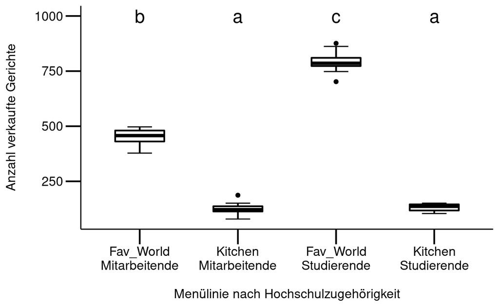

Figure 1: Box-Whisker-Plots der wöchentlichen Verkaufszahlen pro Menü-Inhalte. Kleinbuchstaben bezeichnen homogene Gruppen auf *p* < .05 nach Tukeys post-hoc-Test.